# Week5 case1B

> A study has been made to compare the nicotine contents of two brand of cigarettes. 10 cigarettes of brand A had an average nicotine content of 3.1 milligrams with standard deviation of 0.5 milligrams, while 8 cigarettes of brand B had an average nicotine contents of 2.7 milligrams with standard deviation of 0.7 milligrams. Assuming that two sets of data are independent random samples from normal populations.
> 1. Using F distribution and interval approach, Evaluate the scatterings of nicotine of brand A is always smaller than brand B or not. (assuming 98% confidence interval)

### Premise

- U and V are independent…
- U = Brand B
- V = Brand A  
  Values of B are a numeratoir, and values of A are a denominator.

```r
mat = matrix(c(10, 3.1, 0.5), ncol=3)
mat = rbind(mat, c(8, 2.7, 0.7))
rownames(mat) = c("A", "B")
colnames(mat) = c("freedom", "mean", "stddev")
varA = mat["A", "stddev"] ^ 2
varB = mat["B", "stddev"] ^ 2
dfA = mat["A", "freedom"]-1
dfB = mat["B", "freedom"]-1
crtc = 0.02
conf = 1 - crtc
F1 = qf(crtc/2, dfB, dfA)
F99 = qf(1-crtc/2, dfB, dfA)
seekInterval = function(s1, s2, f){
  return(s2/s1*1/f)
}
```

### Parameters

|  | freedom | mean | stddev |
| --- | --- | --- | --- |
| A | 10 | 3.1 | 0.5 |
| B | 8 | 2.7 | 0.7 |

- A variance = 0.25
- B variance = 0.49
- F at 1% = 0.1488372
- F at 99% = 5.6128655

```r
i2 = seekInterval(varA, varB, F1)
i1 = seekInterval(varA, varB, F99)
```

- interval bottom = 0.3491978
- interval top = 13.1687549

### Premise

- the scatterings of nicotine = true variable of nicotine.
- 0.3491978 < “”B true variance / A true variance“” < 13.1687549 must be true.

### Assumption 1: When B true variance = 0.49

A true variance < 0.49 / 0.3491978  
A true variance < 1.4032164

A true variance > 0.49 / 13.1687549  
A true variance > 0.0372093

0.0372093 < A true variance < 1.4032164

#### A true nicotine contents (1 sigma in interval top)

- B sample = 3.4
- 3.2928971 < A < 4.2845743

### Assumption 2: When A true variance = 0.25

B true variance > 0.3491978 * 0.25  
B true variance > 0.0872994

B true variance < 13.1687549 * 0.25  
B true variance < 3.2921887

0.0872994 < B true variance < 3.2921887

#### B true nicotine contents (1 sigma in interval top)

- A sample = 3.6
- 2.9954648 < B < 4.514439

```r
par(mar=c(5,4,4,5))
curve(dnorm(x, mat["A", "mean"], mat["A", "stddev"]), xlim=c(0, 7), col=2, ylab="")
par(new=T)
```

```r
curve(
  dnorm(x, mat["B", "mean"], mat["B", "stddev"]),
  xlim=c(0, 7), col=3, axes=F, ylab=""
)
par(xpd=T)
```

```r
legend(par()$usr[2], par()$usr[4], legend=rownames(mat), pch=20, col=2:3)
par(new=T)
```

```r
curve(
  df(x, dfA, dfB),
  xlim=c(0, 7), axes=F, ylab=""
)
abline(v=F1, col=4)
```

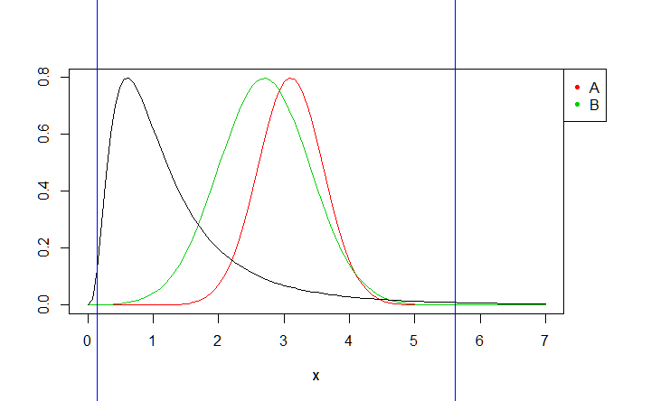

```r
abline(v=F99, col=4)
```